# Tutorial 3 - Recording Computational Traces

This tutorial covers:

- Basics of DCA-style (trace-based) attacks
- How to record computational traces efficiently (`wbkit`)

## Basics of DCA-style attacks

Evaluate the circuit on an input $x^{(1)} = (0, 0, 1)$ and record all input/intermediate/output values:

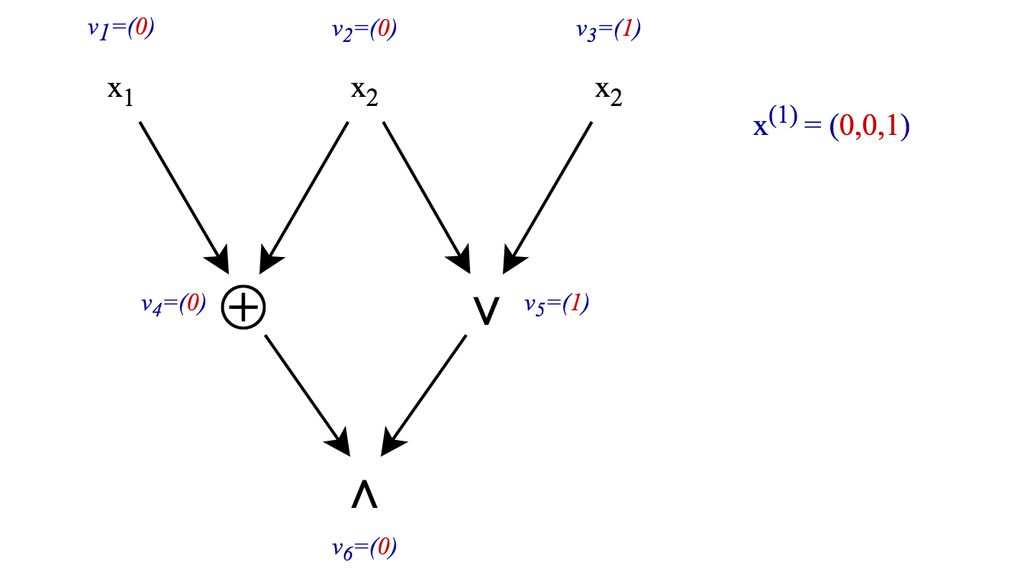

Repeat for another plaintext $x^{(2)} = (0, 1, 0)$, append intermediate values to each node's history.

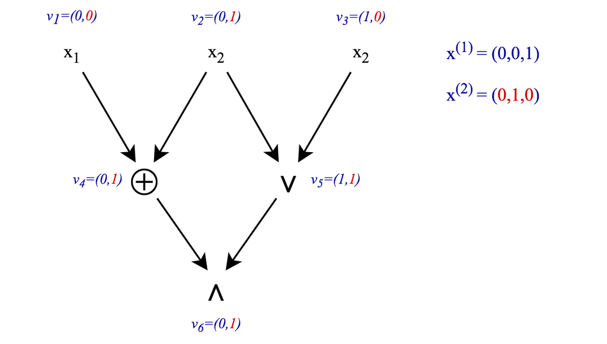

Repeat for another plaintext $x^{(3)} = (1, 1, 1)$.

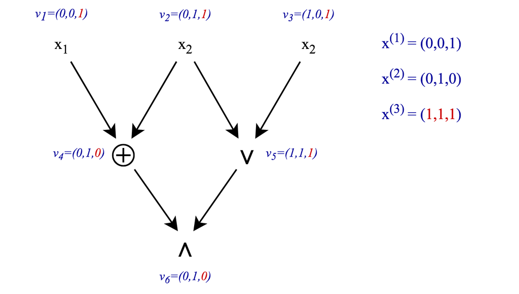

### Setup AES circuit

```python
from binteger import Bin
from circkit.boolean import OptBooleanCircuit as BooleanCircuit
from wbkit.ciphers.aes import BitAES

C = BooleanCircuit(name="AES")

key = b"abcdefghABCDEFGH"
plaintext = b"0123456789abcdef"

pt = C.add_inputs(128)
ct, k10 = BitAES(pt, Bin(key).tuple, rounds=10)
C.add_output(ct)

C.in_place_remove_unused_nodes()
C.print_stats()

ct = C.evaluate(Bin(plaintext).tuple)
```

```
AES(OptBooleanCircuit):
   |   128 inputs,  128 outputs,  31273 nodes
   | XOR:19284 (61.66%), AND:6240 (19.95%), NOT:5621 (17.97%), INPUT:128 (0.41%)
```

## Record computational traces

Using `circkit` directly:

(useful for small experimetns, too slow/heavy for mass tracing)

```python
C.trace(Bin(plaintext).tuple)
```

```
{<OptBooleanCircuit:INPUT[name=x0_0]#0 ()>: 0,
 <OptBooleanCircuit:INPUT[name=x0_1]#1 ()>: 0,
 <OptBooleanCircuit:INPUT[name=x0_2]#2 ()>: 1,
 <OptBooleanCircuit:INPUT[name=x0_3]#3 ()>: 1,
 <OptBooleanCircuit:INPUT[name=x0_4]#4 ()>: 0,
 <OptBooleanCircuit:INPUT[name=x0_5]#5 ()>: 0,
 <OptBooleanCircuit:INPUT[name=x0_6]#6 ()>: 0,
 <OptBooleanCircuit:INPUT[name=x0_7]#7 ()>: 0,
 <OptBooleanCircuit:INPUT[name=x0_8]#8 ()>: 0,
 <OptBooleanCircuit:INPUT[name=x0_9]#9 ()>: 0,
 <OptBooleanCircuit:INPUT[name=x0_10]#10 ()>: 1,
 <OptBooleanCircuit:INPUT[name=x0_11]#11 ()>: 1,
 <OptBooleanCircuit:INPUT[name=x0_12]#12 ()>: 0,
 <OptBooleanCircuit:INPUT[name=x0_13]#13 ()>: 0,
 <OptBooleanCircuit:INPUT[name=x0_14]#14 ()>: 0,
 <OptBooleanCircuit:INPUT[name=x0_15]#15 ()>: 1,
 <OptBooleanCircuit:INPUT[name=x0_16]#16 ()>: 0,
 <OptBooleanCircuit:INPUT[name=x0_17]#17 ()>: 0,
 <OptBooleanCircuit:INPUT[name=x0_18]#18 ()>: 1,
 <OptBooleanCircuit:INPUT[name=x0_19]#19 ()>: 1,
 <OptBooleanCircuit:INPUT[name=x0_20]#20 ()>: 0,
 <OptBooleanCircuit:INPUT[name=x0_21]#21 ()>: 0,
 <OptBooleanCircuit:INPUT[name=x0_22]#22 ()>: 1,
 <OptBooleanCircuit:INPUT[name=x0_23]#23 ()>: 0,
 <OptBooleanCircuit:INPUT[name=x0_24]#24 ()>: 0,
 <OptBooleanCircuit:INPUT[name=x0_25]#25 ()>: 0,
 <OptBooleanCircuit:INPUT[name=x0_26]#26 ()>: 1,
 <OptBooleanCircuit:INPUT[name=x0_27]#27 ()>: 1,
 <OptBooleanCircuit:INPUT[name=x0_28]#28 ()>: 0,
 <OptBooleanCircuit:INPUT[name=x0_29]#29 ()>: 0,
 <OptBooleanCircuit:INPUT[name=x0_30]#30 ()>: 1,
 <OptBooleanCircuit:INPUT[name=x0_31]#31 ()>: 1,
 <OptBooleanCircuit:INPUT[name=x0_32]#32 ()>: 0,
 <OptBooleanCircuit:INPUT[name=x0_33]#33 ()>: 0,
 <OptBooleanCircuit:INPUT[name=x0_34]#34 ()>: 1,
 <OptBooleanCircuit:INPUT[name=x0_35]#35 ()>: 1,
 <OptBooleanCircuit:INPUT[name=x0_36]#36 ()>: 0,
 <OptBooleanCircuit:INPUT[name=x0_37]#37 ()>: 1,
 <OptBooleanCircuit:INPUT[name=x0_38]#38 ()>: 0,
 <OptBooleanCircuit:INPUT[name=x0_39]#39 ()>: 0,
```

[output cut: 946 more lines]

```
 <OptBooleanCircuit:XOR#1110 (147,1109)>: 0,
 <OptBooleanCircuit:NOT#1117 (1110)>: 1,
 <OptBooleanCircuit:NOT#1118 (1096)>: 0,
 <OptBooleanCircuit:NOT#1119 (1107)>: 1,
 <OptBooleanCircuit:NOT#1120 (1105)>: 0,
 <OptBooleanCircuit:NOT#1121 (1104)>: 1,
 <OptBooleanCircuit:NOT#1122 (1097)>: 1,
 <OptBooleanCircuit:NOT#1123 (1103)>: 1,
 <OptBooleanCircuit:XOR#1124 (1122,1120)>: 1,
 <OptBooleanCircuit:XOR#1125 (1123,1121)>: 0,
 <OptBooleanCircuit:XOR#1126 (47,1117)>: 0,
 <OptBooleanCircuit:XOR#1127 (1119,1118)>: 1,
 <OptBooleanCircuit:XOR#1128 (1121,1120)>: 1,
 <OptBooleanCircuit:XOR#1129 (1123,1122)>: 0,
 ...}
```

To do fast recording, we serialize the circuit into an internal binary format, into a file:

```python
from wbkit.serialize import RawSerializer

RawSerializer().serialize_to_file(C, "circuits/aes10_clear.bin")
```

Now, we can use a fast C-based circuit tracer provided by `wbkit`:

```python
from wbkit.fastcircuit import FastCircuit

plaintext = b"0123456789abcdef"

FC = FastCircuit("circuits/aes10_clear.bin")
ciphertext = FC.compute_one(plaintext, trace_filename="traces/test")
ciphertext.hex()
```

```
'54b03463c5b5a1d45efb4e91637ba51f'
```

The key feature is bit-sliced **batch** tracing: using 64-bit CPU registers we can trace 64 executions (inputs) of a Boolean circuit at once. This makes massive tracing much faster.

```python
ciphertexts = FC.compute_batch(
    [b"my_plaintext_abc", b"anotherPlaintext"] * 4,
    trace_filename="traces/test2"
)
ciphertexts
```

```
[b'\xa4\x02\xbcLb\x16\xc9\xcf\x07!\xe2+\xd1\xfb\x177',
 b'>\xdbt\xc3\x8b\x93\xf4\xbf\xb2\x1dZ1\xb7S\x04\xc1',
 b'\xa4\x02\xbcLb\x16\xc9\xcf\x07!\xe2+\xd1\xfb\x177',
 b'>\xdbt\xc3\x8b\x93\xf4\xbf\xb2\x1dZ1\xb7S\x04\xc1',
 b'\xa4\x02\xbcLb\x16\xc9\xcf\x07!\xe2+\xd1\xfb\x177',
 b'>\xdbt\xc3\x8b\x93\xf4\xbf\xb2\x1dZ1\xb7S\x04\xc1',
 b'\xa4\x02\xbcLb\x16\xc9\xcf\x07!\xe2+\xd1\xfb\x177',
 b'>\xdbt\xc3\x8b\x93\xf4\xbf\xb2\x1dZ1\xb7S\x04\xc1']
```

```python
with open("traces/test2", "rb") as f:
    print(f.read(32).hex())
```

```
000000000055ff00ff0000550000aa0000aaff00ff00aaff00aa00000000ffaa
```

## Command-line tracing tool

Since we serialized the circuit to a file, we can use the command-line tracing tool from `wbkit`. It also splits the batches into single-trace files and manages random plaintexts/ciphertexts:

```
> time ../tools/trace.py circuits/aes10_clear.bin 256 traces/
Tracing circuits/aes10_clear.bin on 256 traces
Saving to traces//aes10_clear/
splitting 0
...
splitting 3
> ls -al traces/aes10_clear/ | tail -20
-rw-rw-r-- 1 user user    16 Sep 14 13:21 0249.ct
-rw-rw-r-- 1 user user    16 Sep 14 13:21 0249.pt
-rw-rw-r-- 1 user user  3894 Sep 14 13:21 0250.bin
-rw-rw-r-- 1 user user    16 Sep 14 13:21 0250.ct
-rw-rw-r-- 1 user user    16 Sep 14 13:21 0250.pt
-rw-rw-r-- 1 user user  3894 Sep 14 13:21 0251.bin
-rw-rw-r-- 1 user user    16 Sep 14 13:21 0251.ct
-rw-rw-r-- 1 user user    16 Sep 14 13:21 0251.pt
-rw-rw-r-- 1 user user  3894 Sep 14 13:21 0252.bin
-rw-rw-r-- 1 user user    16 Sep 14 13:21 0252.ct
-rw-rw-r-- 1 user user    16 Sep 14 13:21 0252.pt
-rw-rw-r-- 1 user user  3894 Sep 14 13:21 0253.bin
-rw-rw-r-- 1 user user    16 Sep 14 13:21 0253.ct
-rw-rw-r-- 1 user user    16 Sep 14 13:21 0253.pt
-rw-rw-r-- 1 user user  3894 Sep 14 13:21 0254.bin
-rw-rw-r-- 1 user user    16 Sep 14 13:21 0254.ct
-rw-rw-r-- 1 user user    16 Sep 14 13:21 0254.pt
-rw-rw-r-- 1 user user  3894 Sep 14 13:21 0255.bin
-rw-rw-r-- 1 user user    16 Sep 14 13:21 0255.ct
-rw-rw-r-- 1 user user    16 Sep 14 13:21 0255.pt
```

## Exercise: Trace prepared protected circuits

Create 256 traces for each of the following circuits (serialized in Tutorial 2):

- `circuits/aes2_clear.bin`
- `circuits/aes2_isw2.bin`
- `circuits/aes2_isw3.bin`
- `circuits/aes2_minq.bin`